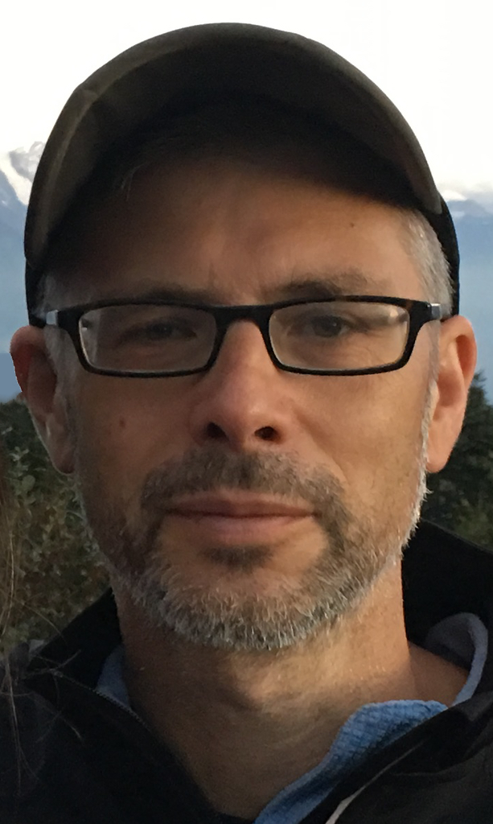

# Ethan Weed

Associate Professor of Linguistics, Aarhus University, Aarhus, Denmark  
Email: ethan@cc.au.dk

## Education and positions

2015- present: Associate Professor, Linguistics, Aarhus University  
2019: Visiting Researcher, Department of Psychology, University of Connecticut, USA  
2014: Visiting Researcher, Department of Psychology, University of Connecticut, USA  
2011-2014: Assistant Professor, Linguistics, Aarhus University  
2011: Research Assistant at MindLab, Center for Functionally Integrative Neuroscience (CFIN), Aarhus University Hospital  
2011 (June 8): PhD in Linguistics from Aarhus University  
2009-2011: PhD fellow Dept. Linguistics, Aarhus University,  
2008: Research assistant at CFIN  
2007: MA in Cognitive Semiotics, Aarhus University  
2003: BA in Spanish from Aarhus University  
1996: BA in Ecology from Hampshire College, USA

## Primary research interests

Clinical Linguistics, Acoustic Phonetics, Clinical Pragmatics, Language Acquisition in Special Populations, Electrophysiological Methods, Natural Language Processing

## Teaching: Courses Taught

Child Language Acquisition: Corpus-Based Approaches; Cognitive Neurolinguistics; Language of the Brain; Psycholinguistics of Second Language Acquisition; Language Challenges in the Classroom; Statistics for Linguists; Development of Language: Language Acquisition; Auditory Neuroscience and Speech Processing; Research Workshop: Dyslexia; Research Workshop: Auditory Processing; Child Language Acquisition; Psycholinguistics; Humanities Elective Language and Cognition; Language, Cognition, and the Brain; Phonetics and Phonology; Studium Generale (Introduction to Philosophy of Science); Text Analysis

## Dissemination

Over 20 invited talks at e.g. DuPont Nutrition and Health, Novozymes A/S, the Danish Organization of Speech Language Pathologists (FTHF), and Chinese Academy of Sciences

## Research Grants

2019-2024: Co-Investigator, National Institute on Deafness and Other Communication Disorders: “Early Predictors to School Age Language: Individual and Interactional Child and Parent Factors”, Letitia Naigles (PI)  
2018-2019: AU Funding for Language as a Tool for Learning Center 2013-2018: Interacting Minds small grants for projects: “Music, Voice, and Auditory Brainstem Response” “Hearing What You’re Thinking” “Clinical Voices” “How well do cloze tests really test reading comprehension in Danish higher-education students?”

#### Reviews for International Journals

Aphasiology; Dyslexia; Journal of Child Language; Journal of Neuroscience; Proc. Nat. Acad. Sci (PNAS); Psychology of Language and Communication; Journal of Neurolinguistics